# Ordre économique bouleversé

Rydch Junior Vincent

Les données utilisées dans ce travail proviennent principalement de [l’OCDE (Organisation de Coopération et de Développement Économiques)](https://data-explorer.oecd.org/), de [l’OMC (Organisation mondiale du commerce)](https://ttd.wto.org/en) et de [l’USITC (U.S. International Trade Commission)](https://dataweb.usitc.gov/).

# 1 Introduction

Depuis les dernières conférences de l’Uruguay Round, qui ont abouti à la création de l’Organisation mondiale du commerce (OMC) en 1995, et l’application mondiale du GATT (Accord général sur les tarifs douaniers et le commerce), le commerce mondial a connu un boom comparativement à l’époque protectionniste où divers pays tentaient de protéger à tout prix leurs industries. Aujourd’hui, cet ordre commercial est remis en question avec le retour au pouvoir du président américain Donald Trump. Connu pour utiliser les tarifs commerciaux comme une arme commerciale et politique, il reste à voir comment les États-Unis, sous l’initiative de leur président, vont affecter l’ordre établi.

L’objectif de ce travail est d’abord d’apprécier les échanges commerciaux dans le monde afin de mettre en avant les dynamiques qui existent entre les différents pays, notamment avec les États-Unis, du moins avant les changements provoqués par les politiques actuelles.

## 1.1 Les acteurs du commerce internationale

[interactive chart not shown]

La part d’un pays dans le commerce international mesure son poids dans l’ensemble des échanges :

$$\text{Part}_{\text{commerce international}} = \left(
\frac{\text{Export}_{\text{pays}} + \text{Import}_{\text{pays}}}{\sum
(\text{Export} + \text{Import})_{\text{monde}}} \right) \times 100$$

On constate, grâce à la carte ci-dessus, que trois pays se démarquent des autres : la Chine, les États-Unis et l’Allemagne ont une importance significative comparativement avec le reste du monde, avec des parts respectives de 14,6 %, 8,4 % et 6,8 %. Le premier est l’usine du monde, le deuxième est une superpuissance économique, tandis que le dernier est réputé pour être la puissance exportatrice de l’Europe. Le volume total des biens échangés de l’un de ces trois pays est si élevé qu’il est supérieur à l’ensemble du continent africain.

Ainsi, pour comprendre cette divergence, il faut remonter aux causes de cette différence, c’est-à-dire analyser le volume des exportations et des importations

### 1.1.1 Exportations par région

[interactive chart not shown]

Il n’est pas surprenant de retrouver ces trois pays comme les plus grands exportateurs de leurs régions respectives. Alors que la position de la Chine et des États-Unis n’est pas contestée, l’Allemagne est rivalisée en Europe par d’autres puissances, comme les Pays-Bas, par exemple.

### 1.1.2 Importations par région

[interactive chart not shown]

Du côté des importations, le leadership n’a pas changé, quoique des différences notables méritent d’être mises en avant. Parmi les trois principaux pays présentés jusqu’ici, l’Allemagne et la Chine ont une part d’importations moins importante que leur part d’exportations, ce qui leur permet de dégager un surplus commercial. Toutefois, la situation est inverse pour les États-Unis : avec une différence de plus de 8 points de pourcentage, les États-Unis importent visiblement plus qu’ils n’exportent, ce qui les place en situation de déficit commercial. Une situation partagée par de nombreux pays européens et asiatiques, comme le montre la comparaison avec ces deux derniers graphiques.

Or, en situation de déficit, un pays est obligé d’emprunter (auprès des pays en situation d’excédent) pour pouvoir financer ses investissements. Si ce déficit se cumule sur plusieurs périodes, cela peut affecter sa capacité à éponger ses dettes.

### 1.1.3 Commerce par zone économique

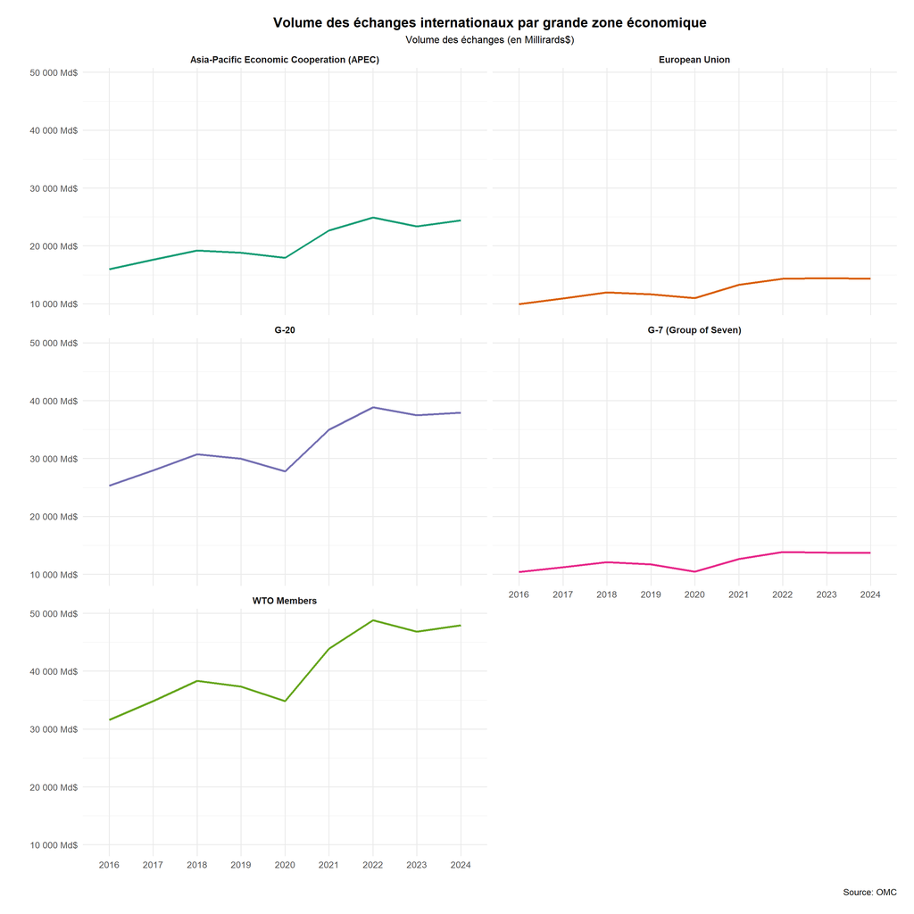

Regroupant 164 pays, l’OMC (Organisation Mondiale du Commerce) est une organisation dont l’un des principaux objectifs est de privilégier le commerce en cherchant à limiter les barrières à l’importation. Il n’est donc pas surprenant de constater que, quel que soit l’année, le volume total des échanges des membres de l’OMC représente le plus important volume d’échanges de biens sur la planète.

Il est également important de souligner que, bien que les membres de l’OMC adhèrent aux mêmes principes, il existe néanmoins des accords bilatéraux en dehors de la charte de l’organisation. De plus, tous les pays du monde participent, dans une certaine mesure, au commerce international, ce qui a conduit à la création de multiples alliances visant à se protéger ou à promouvoir un agenda favorable aux membres d’un groupe.

Ainsi, on retrouve le G20 (groupe des 20), qui regroupe les 19 plus grandes économies mondiales et l’Union Européenne (bloc économique ayant un poids conséquent dans le commerce mondial), ou encore le G7 (groupe des 7) avec les économies les plus développées.

En outre, un autre groupe, en forte croissance grâce aux avancées économiques des pays d’Asie, est l’APEC (Coopération économique pour l’Asie-Pacifique), qui favorise la coopération et la croissance dans un cadre moins formel que l’OMC ou l’Union Européenne.

Ce volume d’échanges important entre les pays du monde rappelle à quel point nous ne vivons plus en autarcie. Posséder un avantage comparatif permet de dégager des gains grâce au commerce international.

## 1.2 Échanges nettes

[interactive chart not shown]

Comme mentionné plus haut, on peut ici constater l’ampleur du déficit commercial de certains pays pour l’année 2024. Ainsi, les États-Unis affichent une perte commerciale de plus de 1 000 milliards de dollars, bien loin du Royaume-Uni avec un déficit déclaré de 303 milliards ou de l’Inde avec près de 259 milliards. Le déficit de la première puissance économique est quatre fois plus élevé que celui du second déficit le plus important. Un déficit énorme qui peut avoir de grandes conséquences sur sa monnaie, par exemple. La demande constante de devises étrangères pour soutenir les achats peut entraîner une perte de valeur de la monnaie. Ce chiffre sous-entend également une certaine dépendance vis-à-vis de l’extérieur, ce qui rend le pays vulnérable en cas de chocs externes, comme une hausse des prix chez les partenaires commerciaux.

## 1.3 Relation bilatérale des États-Unis

[interactive chart not shown]

Pour comprendre l’ampleur du déficit de la superpuissance mondiale, il est nécessaire de s’intéresser à ses dits partenaires commerciaux. On constate que les principaux exportateurs des États-Unis sont dans la même région, à l’exception de la Chine. Si l’on se base sur les données les plus récentes concernant les importations des entreprises américaines, on remarque que celles-ci entretiennent une relation commerciale privilégiée avec les entreprises chinoises, avec lesquelles elles importent pour plus de 497 milliards de dollars.  
Le déficit commercial et cette dépendance grandissante vis-à-vis de la Chine sont l’une des raisons qui expliquent la première guerre commerciale sous le premier mandat de l’administration Trump.

### 1.3.1 Importations avec la Chine

[interactive chart not shown]

Lorsque l’on se focalise sur la répartition par famille des produits importés de Chine, on peut déceler des informations importantes. Les machines électriques et non électriques, ainsi que les produits manufacturés, représentent environ 60 % des importations en provenance de Chine en 2022. Cela témoigne d’un fort besoin en produits industriels fabriqués par les différentes entreprises de l’autre côté du Pacifique. On peut même supposer une domination des entreprises chinoises dans le secteur industriel et une baisse de compétitivité des États-Unis.

### 1.3.2 Droits de douane

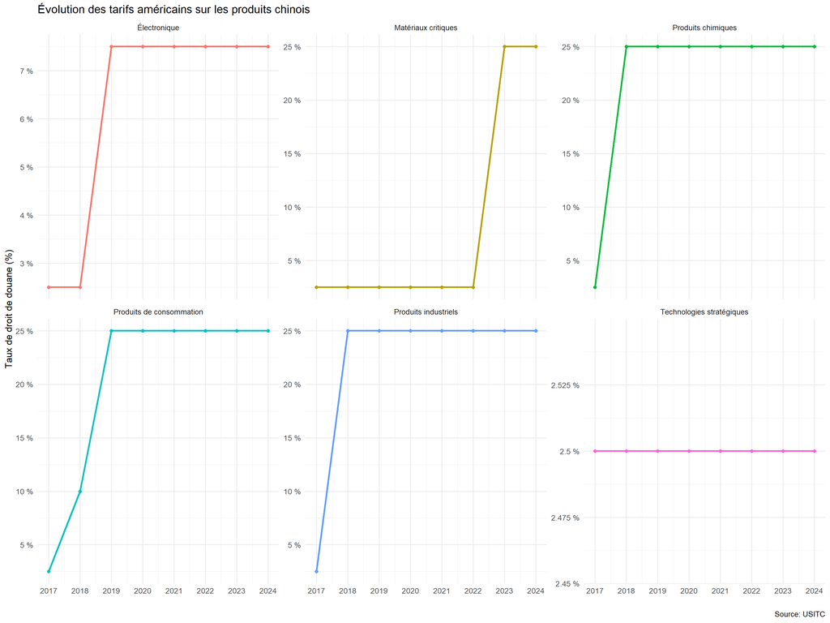

En somme, nous avons vu que les États-Unis sont en déficit commercial, et l’un des pays qui se partagent la part du lion de ce déficit est la Chine. En réponse à cette dépendance grandissante et en raison de la compétition qui existe entre ces deux grandes puissances, le gouvernement américain a imposé des tarifs pour essayer de mitiger la situation, en mettant en avant la protection de leurs marchés face à un ensemble de politiques déloyales des concurrents chinois, jugés irrespectueux des normes environnementales.

# 2 Conclusion

On a montré dans ce travail que le géant asiatique et le géant américain entretiennent une relation commerciale complexe. De plus, suite au développement rapide de la Chine, qui lui a permis de se hisser à une place de choix sur l’échiquier mondial, les divergences politiques entre ces deux grandes puissances sont à leur paroxysme.

La Chine, en guise de rétorsion, a elle aussi augmenté ses tarifs douaniers, tout en cherchant à développer de meilleures relations commerciales avec d’autres pays asiatiques, ainsi qu’avec l’Europe. Cela a eu un impact considérable sur les exportations des États-Unis. Toutefois, tout bon économiste dira que les exportations génèrent les importations : moins on exporte, moins on importe. Mais là où le bas blesse, c’est pour le consommateur américain, qui a vu les prix de certains produits (ceux en provenance de Chine) augmenter de manière significative, surtout dans les secteurs où la demande est moins sensible au prix. D’un autre côté, dans les secteurs où la demande est plus élastique, les producteurs ont dû sacrifier leurs marges.

Revenu à la Maison-Blanche, le président Donald Trump a promis d’augmenter les tarifs, allant cette fois jusqu’à **45 %**. On se pose déjà des questions sur l’efficacité de telles mesures, étant donné les résultats contestés de la première guerre commerciale. Force est de constater que le monde, après des décennies d’ouverture, semble être en train de se refermer sur lui-même. On peut alors se demander : face aux différents défis du quotidien, est-ce que les personnes les plus pauvres ne seront pas davantage en difficulté dans ce nouvel ordre économique ?